# Tubes Statistika

Kelompok C

**Maksud Eksplorasi**  
Kelompok kami mendapatkan data tentang Engineering Graduate Salary yang berisi data-data mengenai info terkait ID, gender, DOB, 10percentage, 10board, 12graduation, 12percentage, 12board, CollegeID, College Tier dan banyak data yang lainnya yang dapat kita eksplor. Maksud dari eksplorasi data ini kami ingin memperlihatkan data dari Engineering Graduate Salary berupa visualisasi dari data tersebut mulai dari Eksplorasi data univariant, Eksplorasi data bivariant, maupun Eksplorasi data multivariant serta melakukan analisis data yang telah didapatkan satu persatu.

**Variable yang di Eksplor**  
Dari semua variable yang ada dalam data Engineering Graduate Salary, kami memilih sebanyak lima variabel yang akan di Eksplor. Lima variabel tersebut yaitu :  
• College GPA  
• English  
• Logical  
• Salary  
• Gender (digunakan hanya pada Boxplot multivariant)

**Alat dan Metode**  
Untuk Alat yang kami gunakan dalam melakukan eksplorasi data ini yaitu dengan menggunakan Rstudio. Rstudio ini merupakan bahasa pemrograman yang paling sering digunakan untuk melakukan Eksplorasi serta Visualisasi dari suatu data. Metode yang kami gunakan untuk eksplorasi data ini yaitu Eksplorasi data univariant yang berisikan : histogram dan boxplot, Ekplorasi data bivariant yang berisikan : scatterplot, dan Eksplorasi data multi variant yang berisikan : ggpairs, boxplot multivariant atau multi dimensi.

```r
# load libraries
#df <- read_excel("~/Downloads/Engineering_graduate_salary.xlsx")
library(readr)
library(dplyr)
library(ggplot2)
library(GGally)
```

```r
#load data frames
df <- read_excel("~/Downloads/Engineering_graduate_salary.xlsx")
```

```r
#inspect data frames
head(df)
```

| ID | Gender | DOB | 10percentage | 10board | 12graduation | 12percentage | 12board | CollegeID | CollegeTier | Degree | Specialization | collegeGPA | CollegeCityID | CollegeCityTier | CollegeState | GraduationYear | English | Logical | Quant | Domain | ComputerProgramming | ElectronicsAndSemicon | ComputerScience | MechanicalEngg | ElectricalEngg | TelecomEngg | CivilEngg | conscientiousness | agreeableness | … |
| --- | --- | --- | --- | --- | --- | --- | --- | --- | --- | --- | --- | --- | --- | --- | --- | --- | --- | --- | --- | --- | --- | --- | --- | --- | --- | --- | --- | --- | --- | --- |
| 604399 | f | 1990-10-22 | 87.80 | cbse | 2009 | 84.00 | cbse | 6920 | 1 | B.Tech/B.E. | instrumentation and control engineering | 73.82 | 6920 | 1 | Delhi | 2013 | 650 | 665 | 810 | 0.6944793 | 485 | 366 | -1 | -1 | -1 | -1 | -1 | -0.1590 | 0.3789 | … |
| 988334 | m | 1990-05-15 | 57.00 | cbse | 2010 | 64.50 | cbse | 6624 | 2 | B.Tech/B.E. | computer science & engineering | 65.00 | 6624 | 0 | Uttar Pradesh | 2014 | 440 | 435 | 210 | 0.3423149 | 365 | -1 | -1 | -1 | -1 | -1 | -1 | 1.1336 | 0.0459 | … |
| 301647 | m | 1989-08-21 | 77.33 | maharashtra state board,pune | 2007 | 85.17 | amravati divisional board | 9084 | 2 | B.Tech/B.E. | electronics & telecommunications | 61.94 | 9084 | 0 | Maharashtra | 2011 | 485 | 475 | 505 | 0.8246664 | -1 | 400 | -1 | -1 | -1 | 260 | -1 | 0.5100 | -0.1232 | … |
| 582313 | m | 1991-05-04 | 84.30 | cbse | 2009 | 86.00 | cbse | 8195 | 1 | B.Tech/B.E. | computer science & engineering | 80.40 | 8195 | 1 | Delhi | 2013 | 675 | 620 | 635 | 0.9900088 | 655 | -1 | -1 | -1 | -1 | -1 | -1 | -0.4463 | 0.2124 | … |
| 339001 | f | 1990-10-30 | 82.00 | cbse | 2008 | 75.00 | cbse | 4889 | 2 | B.Tech/B.E. | biotechnology | 64.30 | 4889 | 1 | Tamil Nadu | 2012 | 575 | 495 | 365 | 0.2784574 | 315 | -1 | -1 | -1 | -1 | -1 | -1 | -1.4992 | -0.7473 | … |
| 609356 | f | 1989-12-02 | 83.16 | icse | 2007 | 77.00 | cbse | 10950 | 1 | M.Tech./M.E. | instrumentation and control engineering | 99.93 | 10950 | 0 | Punjab | 2013 | 535 | 595 | 620 | 0.3760596 | 455 | 300 | -1 | -1 | -1 | 313 | -1 | 0.8463 | -0.6201 | … |

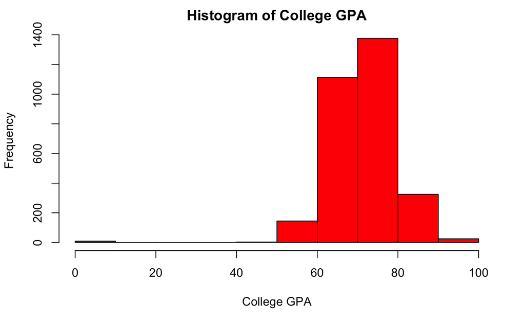

```r
data <- df
hist(
  df$collegeGPA, col="red", main="Histogram of College GPA", xlab="College GPA", border="black"
)
```

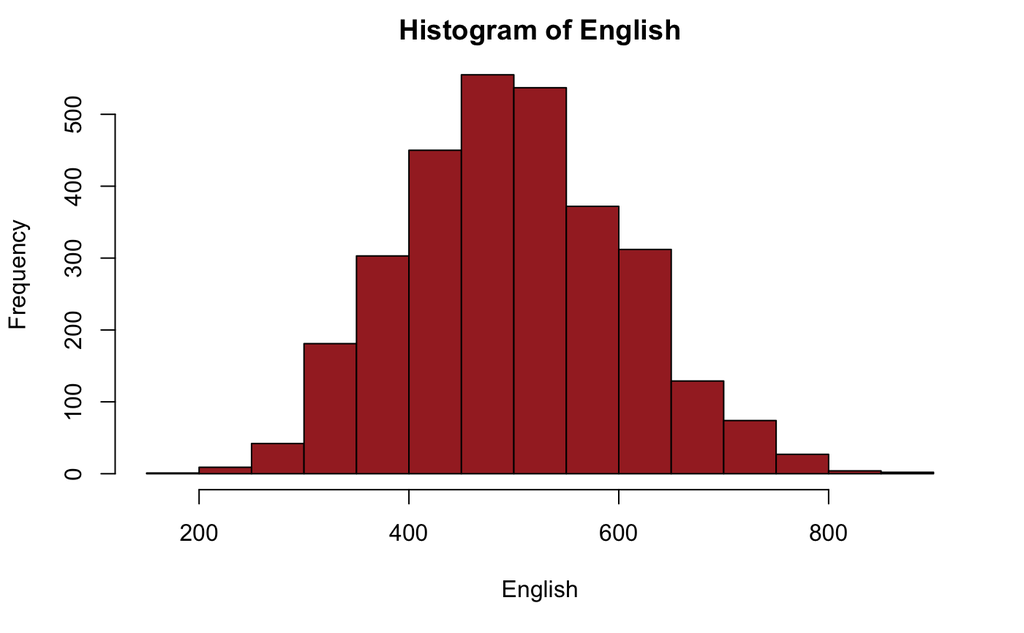

```r
data <- df
hist(
  df$English, col="brown", main="Histogram of English", xlab="English", border="black"
)
```

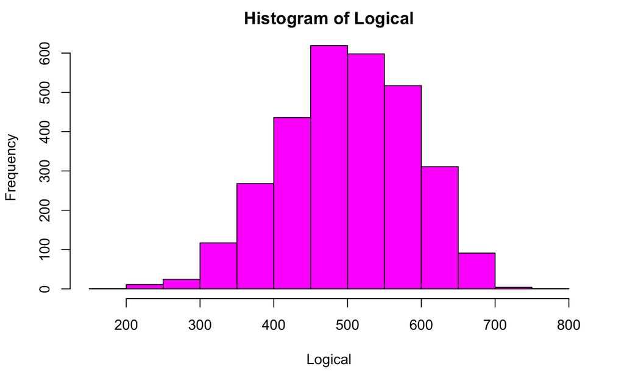

```r
data <- df
hist(
  df$Logical, col="magenta", main="Histogram of Logical", xlab="Logical", border="black"
)
```

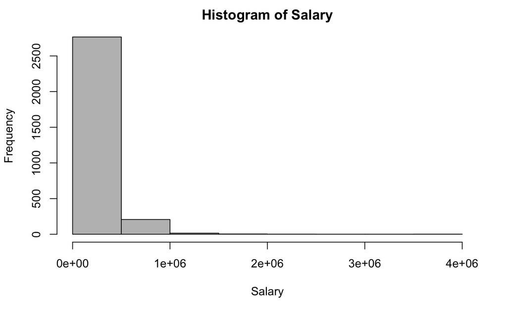

```r
# labels=sprintf("$%2.0f", seq(10,400,by=100))
hist(
  df$Salary, col="grey", main="Histogram of Salary", xlab="Salary", border="black"
)
```

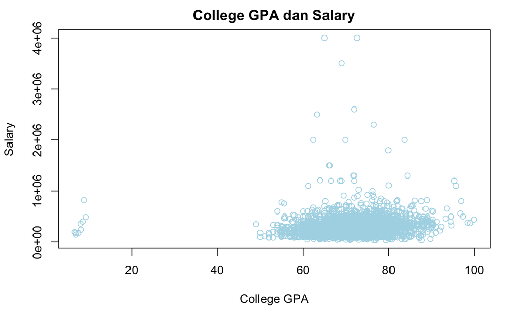

```r
plot(
  df$collegeGPA, df$Salary, main = "College GPA dan Salary",ylab="Salary", xlab="College GPA", col="lightblue"
)
```

```r
cor.test(df$collegeGPA,df$Salary, method = 'pearson')
```

```
    Pearson's product-moment correlation

data:  df$collegeGPA and df$Salary
t = 7.2839, df = 2996, p-value = 4.126e-13
alternative hypothesis: true correlation is not equal to 0
95 percent confidence interval:
 0.09656911 0.16692172
sample estimates:
      cor
0.1319115
```

**Eksplorasi data Bivariant**  
1. Variabel College GPA dan Salary Dari scatter plot antara College GPA dengan Salary, didapatkan hubungan atau korelasi dari corelation test metode pearson yang bersifat positif lemah dan data pada plot tersebut ada yang menyebar dan ada juga yang menumpuk. Selain itu, didapatkan banyak pemusatan data yang menumpuk dari rentang 45 – 85.

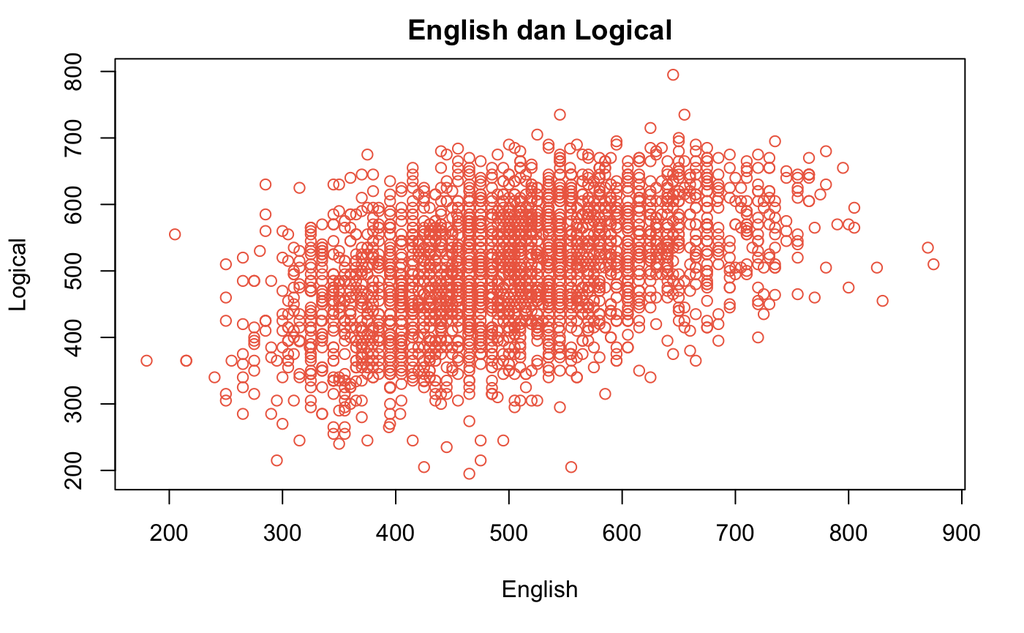

```r
plot(
  df$English, df$Logical, main = "English dan Logical",ylab="Logical", xlab="English", col="coral2"
)
```

```r
cor.test(df$English,df$Logical, method = 'pearson')
```

```
    Pearson's product-moment correlation

data:  df$English and df$Logical
t = 26.922, df = 2996, p-value < 2.2e-16
alternative hypothesis: true correlation is not equal to 0
95 percent confidence interval:
 0.4120699 0.4697344
sample estimates:
      cor
0.4413577
```

**Eksplorasi data Bivariant**  
2. Variabel English dan Logical Dari scatter plot antara English dengan Logical, didapatkan hubungan atau korelasi didapatkan hubungan atau korelasi dari corelation test metode pearson yang bersifat positif lemah. Selain itu, didapatkan banyak pemusatan data ditengah – tengah dari rentang 300 – 750 dan ditemukan juga 1 data plot yang kurang dari 200.

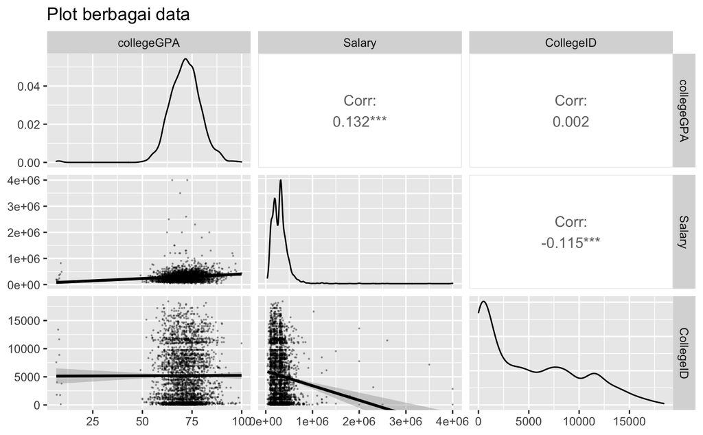

```r
# Menampilkan korelasi antar kombinasi pasangan fitur dataset
data %>%
  select(collegeGPA, Salary, CollegeID) %>%
  ggpairs(
    title="Plot berbagai data", lower=list(continuous=wrap("smooth", alpha= 0.3, size=0.1))
  )
```

**Eksplorasi Data Multivariant**  
1. Variabel College GPA, Salary, dan College ID Dari hasil ggpairs diatas, didapatkan korelasi antara College GPA, Salary, dan College ID. Dari beberapa korelasi tersebut, ditemukan 3 korelasi yaitu antara Salary dengan college GPA, College ID dengan College GPA, dan College ID dengan Salary. Salary dengan college GPA dan College ID dengan College GPA memiliki korelasi positif lemah. Sementara College ID dengan Salary memiliki korelasi negatif lemah.

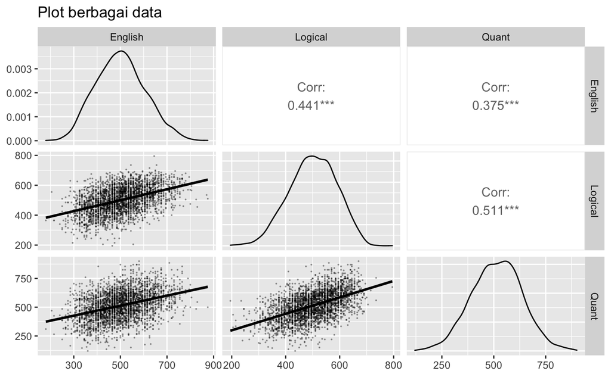

```r
# Menampilkan korelasi antar kombinasi pasangan fitur dataset
data %>%
  select(English, Logical, Quant) %>%
  ggpairs(
    title="Plot berbagai data", lower=list(continuous=wrap("smooth", alpha= 0.3, size=0.1))
  )
```

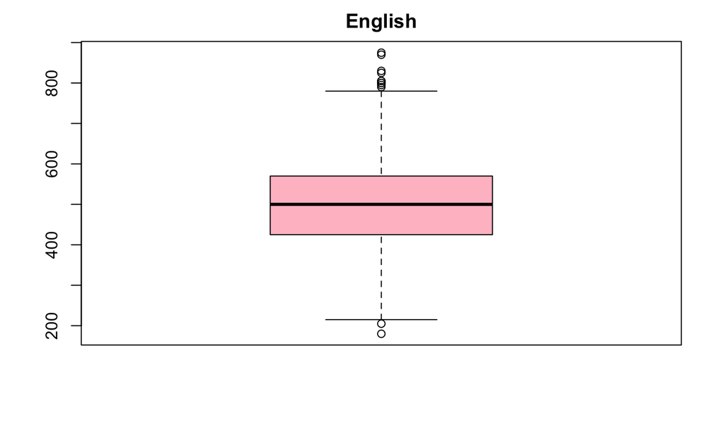

```r
boxplot(df$English, col = "pink", main ="English")
```

```r
summary(df$English)
```

```
   Min. 1st Qu.  Median    Mean 3rd Qu.    Max.
  180.0   425.0   500.0   501.1   570.0   875.0
```

**Eksplorasi Data Univariant**  
1. Analisis Variabel English Q1 = 425, Median = 500, Q3= 570. Dari visualisai boxplot diatas, dapat diketahui bahwa dari boxplot tersebut terdapat pencilan atas dan pencilan bawah meskipun pencilan atas lebih banyak dari pada pencilan bawah. Hal ini menunjukkan adanya kemencengan atau kecenderungan positif. Sehingga didapatkan penyebaran distribusi data yang simetris pada boxplot.

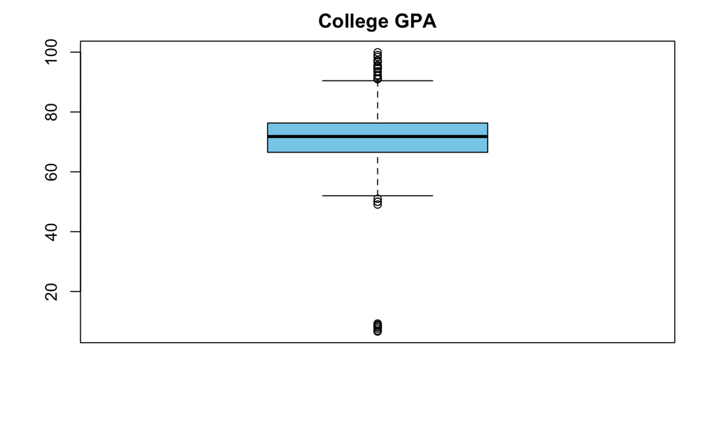

```r
boxplot(df$collegeGPA, col = "skyblue", main ="College GPA")
```

```r
summary(df$collegeGPA)
```

```
   Min. 1st Qu.  Median    Mean 3rd Qu.    Max.
   6.63   66.53   71.80   71.51   76.30   99.93
```

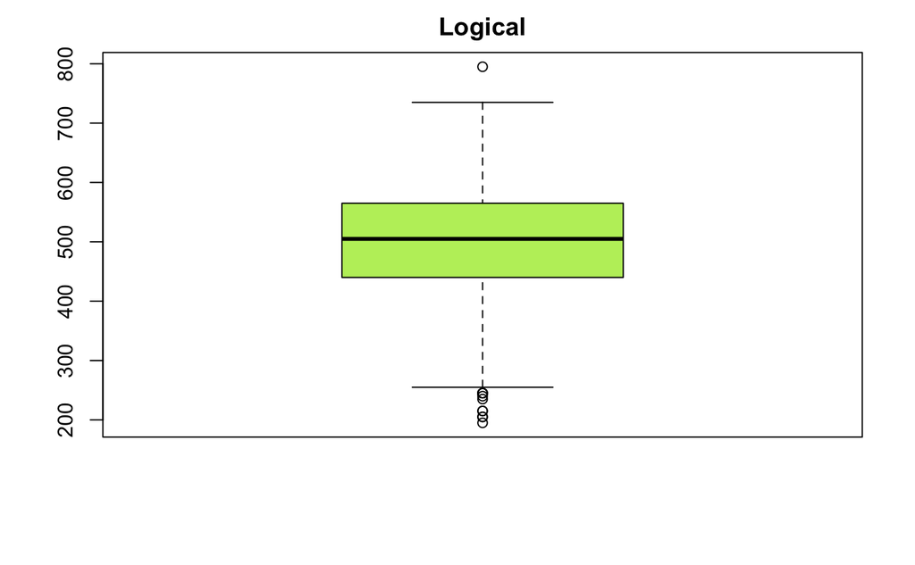

```r
boxplot(df$Logical, col = "darkolivegreen2", main ="Logical")
```

```r
summary(df$Logical)
```

```
   Min. 1st Qu.  Median    Mean 3rd Qu.    Max.
  195.0   441.2   505.0   500.4   565.0   795.0
```

**Eksplorasi Data Univariant**  
3. Variabel Logical Q1 = 441.2, Median = 505, Q3 = 565 . Dari visualisai boxplot diatas, dapat diketahui bahwa dari boxplot tersebut terdapat pencilan atas dan pencilan bawah meskipun pencilan bawah lebih banyak dari pada pencilan atas. Hal ini menunjukkan adanya kemencengan atau kecenderungan ke arah yang negatif. Sehingga didapatkan penyebaran distribusi data yang simetris pada boxplot.

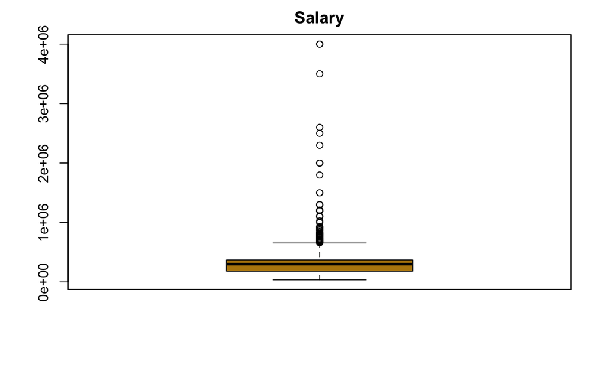

```r
boxplot(df$Salary, col = "darkgoldenrod", main ="Salary")
```

```r
summary(df$Salary)
```

```
   Min. 1st Qu.  Median    Mean 3rd Qu.    Max.
  35000  180000  300000  305175  370000 4000000
```

**Eksplorasi Data Univariant**  
4. Variabel Salary Q1 = 180000, Median = 300000, Q3 = 370000. Dari visualisai boxplot diatas, dapat diketahui bahwa dari boxplot tersebut hanya terdapat pencilan atas yang sangat banyak. Hal ini menunjukkan adanya kemencengan atau kecenderungan ke arah yang positif. Sehingga didapatkan penyebaran distribusi data yang hampir mendekati kuartil 3 pada boxplot.

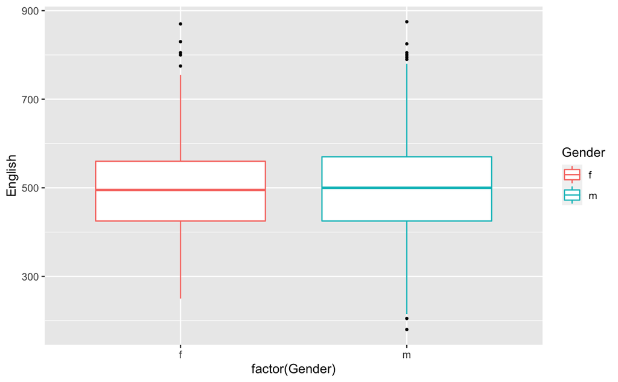

```r
ggplot(data, aes(x = factor(Gender), color = Gender, y = English)) +
  geom_boxplot(outlier.colour="black", outlier.shape=16, outlier.size=1, notch=FALSE)
```

**Eksplorasi Data Multivariant**  
- Variabel English dengan Variabel gender Dari visualisasi data diatas, dapat diketahui bahwa skor inggris yang dimiliki male dan female dari boxplot tersebut bersifat simetris karena mediannya berada ditengah-tengah. Selain itu, dapat dilihat bahwa di boxplot female memiliki pencilan atas sementara male memiliki pencilan atas dan bawah.